# Practical Machine Learning Assignment

Chen Fuwei

22 May 2017

## Introduction

This report describes how a model was built to predict the manner in which participants performed barbell lifts. This is based on data from accelerometers on the belt, forearm, arm, and dumbell of 6 participants, who were asked to perform barbell lifts correctly and incorrectly in 5 different ways - exactly according to the specification (Class A), throwing the elbows to the front (Class B), lifting the dumbbell only halfway (Class C), lowering the dumbbell only halfway (Class D) and throwing the hips to the front (Class E). The prediction model was also used to predict 20 different test cases.

## Data Loading and Exploratory Analysis

The relevant working directory was set and the necessary R libraries uploaded.

```r
setwd("C:/Users/Admin/Desktop/Data Science/8. Machine Learning")
library(knitr)
library(lattice)
library(caret)
```

```r
library(rpart)
library(rpart.plot)
library(RGtk2)
library(rattle)
library(randomForest)
library(corrplot)
set.seed(54321)
```

The dataset was downloaded from the relevant URL. The training dataset was then partitioned into two to create a Training set (60% of the data) for the modelling process and a Test set (with the remaining 40%) for validation. The testing dataset was not changed and would be used to generate the quiz results.

```r
# setting the url for data download
TrainUrl <- "http://d396qusza40orc.cloudfront.net/predmachlearn/pml-training.csv"
TestUrl  <- "http://d396qusza40orc.cloudfront.net/predmachlearn/pml-testing.csv"

# downloading the datasets
training <- read.csv(url(TrainUrl))
testing  <- read.csv(url(TestUrl))

# partitioning the training dataset
inTrain  <- createDataPartition(training$classe, p=0.6, list=FALSE)
TrainSet <- training[inTrain, ]
TestSet  <- training[-inTrain, ]
dim(TrainSet)
```

```
## [1] 11776   160
```

Data was cleaned to remove variables with near zero variance or mostly NA values, as well as identification variables.

```r
# removing variables with near zero variance
nzerovar <- nearZeroVar(TrainSet)
TrainSet <- TrainSet[, -nzerovar]
TestSet  <- TestSet[, -nzerovar]
dim(TrainSet)
```

```
## [1] 11776   108
```

```r
dim(TestSet)
```

```
## [1] 7846  108
```

```r
# removing variables that with mostly NA values
MostlyNA    <- sapply(TrainSet, function(x) mean(is.na(x))) > 0.95
TrainSet <- TrainSet[, MostlyNA==FALSE]
TestSet  <- TestSet[, MostlyNA==FALSE]
dim(TrainSet)
```

```
## [1] 11776    59
```

```r
dim(TestSet)
```

```
## [1] 7846   59
```

```r
# removing ID variables (columns 1 to 5)
TrainSet <- TrainSet[, -(1:5)]
TestSet  <- TestSet[, -(1:5)]
dim(TrainSet)
```

```
## [1] 11776    54
```

```r
dim(TestSet)
```

```
## [1] 7846   54
```

## Model Building

Three methods were applied to model the regressions (in the Train dataset) and the best one (with the highest accuracy when applied to the Test dataset) would be used for the quiz predictions. The methods used wre: Random Forest, Decision Tree and Generalized Boosted Model. Confusion Matrices were derived to ascertain the accuracy of the models.

### Random Forest Model

```r
# model fit
set.seed(54321)
ctrlRF <- trainControl(method="cv", number=3, verboseIter=FALSE)
modRF <- train(classe ~ ., data=TrainSet, method="rf",
                          trControl=ctrlRF)
modRF$finalModel
```

```
##
## Call:
##  randomForest(x = x, y = y, mtry = param$mtry)
##                Type of random forest: classification
##                      Number of trees: 500
## No. of variables tried at each split: 27
##
##         OOB estimate of  error rate: 0.24%
## Confusion matrix:
##      A    B    C    D    E  class.error
## A 3347    0    0    0    1 0.0002986858
## B    7 2269    3    0    0 0.0043878894
## C    0    3 2051    0    0 0.0014605648
## D    0    0    7 1922    1 0.0041450777
## E    0    0    0    6 2159 0.0027713626
```

```r
# prediction on Test dataset
predictRF <- predict(modRF, newdata=TestSet)
confMatRF <- confusionMatrix(predictRF, TestSet$classe)
confMatRF
```

```
## Confusion Matrix and Statistics
##
##           Reference
## Prediction    A    B    C    D    E
##          A 2232    8    0    0    0
##          B    0 1508    2    0    0
##          C    0    2 1366    5    0
##          D    0    0    0 1281    3
##          E    0    0    0    0 1439
##
## Overall Statistics
##
##                Accuracy : 0.9975
##                  95% CI : (0.9961, 0.9984)
##     No Information Rate : 0.2845
##     P-Value [Acc > NIR] : < 2.2e-16
##
##                   Kappa : 0.9968
##  Mcnemar's Test P-Value : NA
##
## Statistics by Class:
##
##                      Class: A Class: B Class: C Class: D Class: E
## Sensitivity            1.0000   0.9934   0.9985   0.9961   0.9979
## Specificity            0.9986   0.9997   0.9989   0.9995   1.0000
## Pos Pred Value         0.9964   0.9987   0.9949   0.9977   1.0000
## Neg Pred Value         1.0000   0.9984   0.9997   0.9992   0.9995
## Prevalence             0.2845   0.1935   0.1744   0.1639   0.1838
## Detection Rate         0.2845   0.1922   0.1741   0.1633   0.1834
## Detection Prevalence   0.2855   0.1925   0.1750   0.1637   0.1834
## Balanced Accuracy      0.9993   0.9965   0.9987   0.9978   0.9990
```

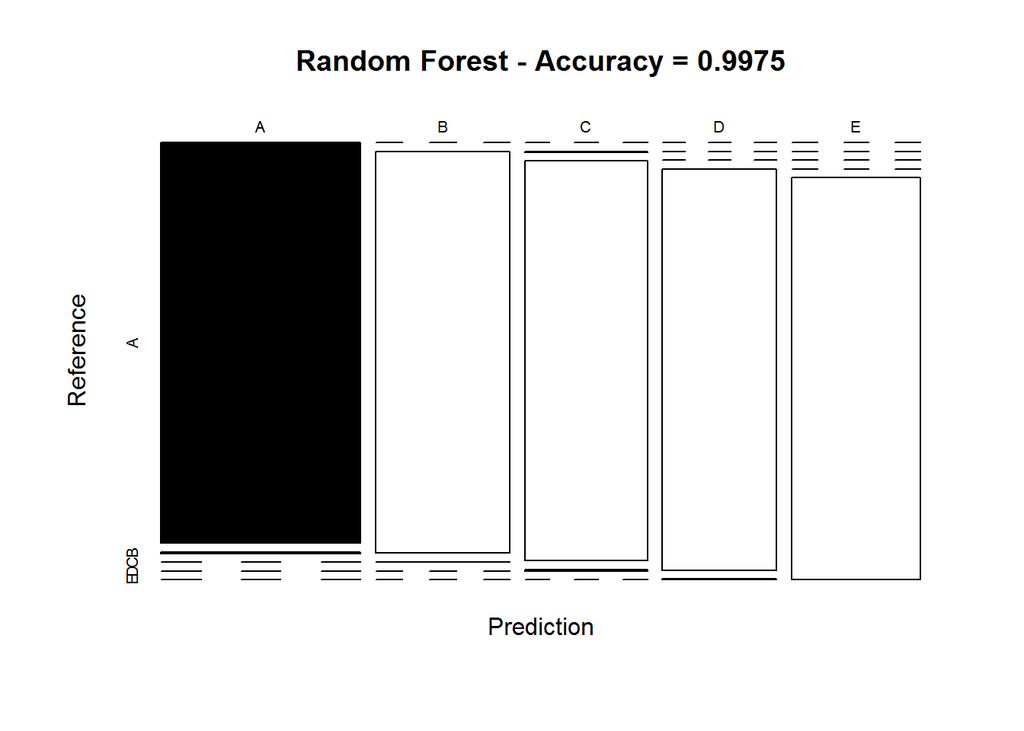

```r
# plot matrix results
plot(confMatRF$table, col = confMatRF$byClass,
     main = paste("Random Forest - Accuracy =",
                  round(confMatRF$overall['Accuracy'], 4)))
```

### Decision Tree Model

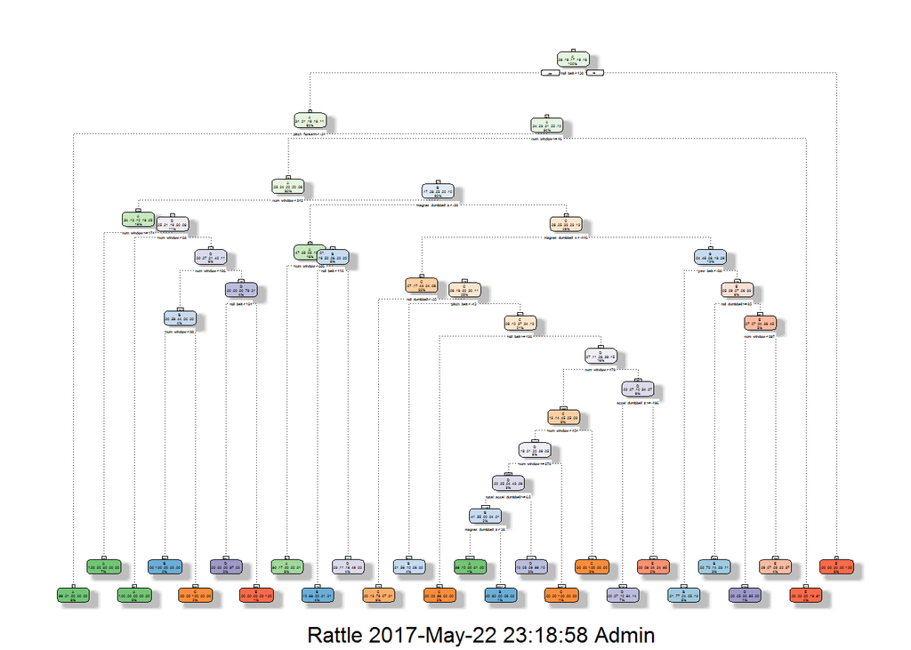

```r
# model fit
set.seed(54321)
modDT <- rpart(classe ~ ., data=TrainSet, method="class")
fancyRpartPlot(modDT)
```

```r
# prediction on Test dataset
predictDT <- predict(modDT, newdata=TestSet, type="class")
confMatDT <- confusionMatrix(predictDT, TestSet$classe)
confMatDT
```

```
## Confusion Matrix and Statistics
##
##           Reference
## Prediction    A    B    C    D    E
##          A 1914  114    1   19    7
##          B  144 1187   86   55   92
##          C    0   81 1143   59    5
##          D  128  109  106  986   94
##          E   46   27   32  167 1244
##
## Overall Statistics
##
##                Accuracy : 0.8251
##                  95% CI : (0.8165, 0.8335)
##     No Information Rate : 0.2845
##     P-Value [Acc > NIR] : < 2.2e-16
##
##                   Kappa : 0.7795
##  Mcnemar's Test P-Value : < 2.2e-16
##
## Statistics by Class:
##
##                      Class: A Class: B Class: C Class: D Class: E
## Sensitivity            0.8575   0.7819   0.8355   0.7667   0.8627
## Specificity            0.9749   0.9404   0.9776   0.9334   0.9575
## Pos Pred Value         0.9314   0.7590   0.8874   0.6929   0.8206
## Neg Pred Value         0.9451   0.9473   0.9657   0.9533   0.9687
## Prevalence             0.2845   0.1935   0.1744   0.1639   0.1838
## Detection Rate         0.2439   0.1513   0.1457   0.1257   0.1586
## Detection Prevalence   0.2619   0.1993   0.1642   0.1814   0.1932
## Balanced Accuracy      0.9162   0.8612   0.9066   0.8501   0.9101
```

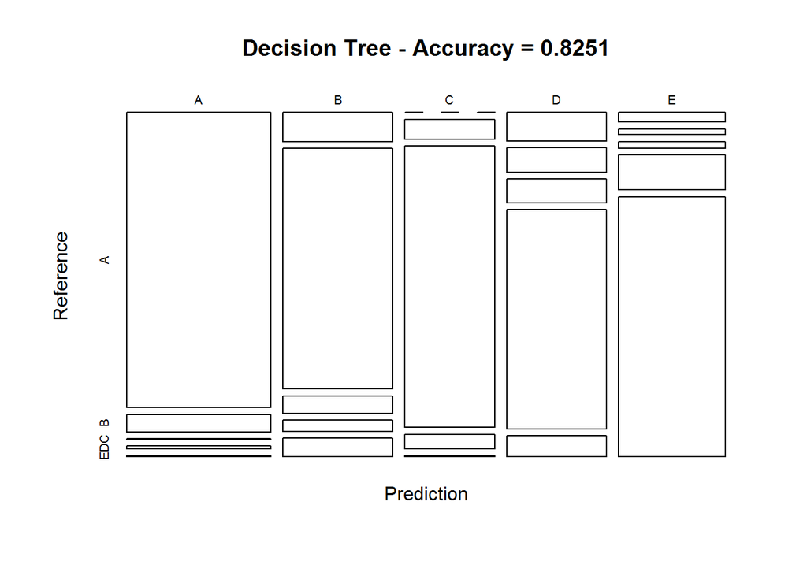

```r
# plot matrix results
plot(confMatDT$table, col = confMatDT$byClass,
     main = paste("Decision Tree - Accuracy =",
                  round(confMatDT$overall['Accuracy'], 4)))
```

### Generalised Boosted Model

```r
# model fit
set.seed(54321)
ctrlGBM <- trainControl(method = "repeatedcv", number = 5, repeats = 1)
modGBM  <- train(classe ~ ., data=TrainSet, method = "gbm",
                    trControl = ctrlGBM, verbose = FALSE)
modGBM$finalModel
```

```
## A gradient boosted model with multinomial loss function.
## 150 iterations were performed.
## There were 53 predictors of which 45 had non-zero influence.
```

```r
# prediction on Test dataset
predictGBM <- predict(modGBM, newdata=TestSet)
confMatGBM <- confusionMatrix(predictGBM, TestSet$classe)
confMatGBM
```

```
## Confusion Matrix and Statistics
##
##           Reference
## Prediction    A    B    C    D    E
##          A 2216   18    0    2    3
##          B   16 1482    6    6    3
##          C    0   15 1360   18    3
##          D    0    2    2 1259    3
##          E    0    1    0    1 1430
##
## Overall Statistics
##
##                Accuracy : 0.9874
##                  95% CI : (0.9847, 0.9897)
##     No Information Rate : 0.2845
##     P-Value [Acc > NIR] : < 2.2e-16
##
##                   Kappa : 0.984
##  Mcnemar's Test P-Value : NA
##
## Statistics by Class:
##
##                      Class: A Class: B Class: C Class: D Class: E
## Sensitivity            0.9928   0.9763   0.9942   0.9790   0.9917
## Specificity            0.9959   0.9951   0.9944   0.9989   0.9997
## Pos Pred Value         0.9897   0.9795   0.9742   0.9945   0.9986
## Neg Pred Value         0.9971   0.9943   0.9988   0.9959   0.9981
## Prevalence             0.2845   0.1935   0.1744   0.1639   0.1838
## Detection Rate         0.2824   0.1889   0.1733   0.1605   0.1823
## Detection Prevalence   0.2854   0.1928   0.1779   0.1614   0.1825
## Balanced Accuracy      0.9944   0.9857   0.9943   0.9890   0.9957
```

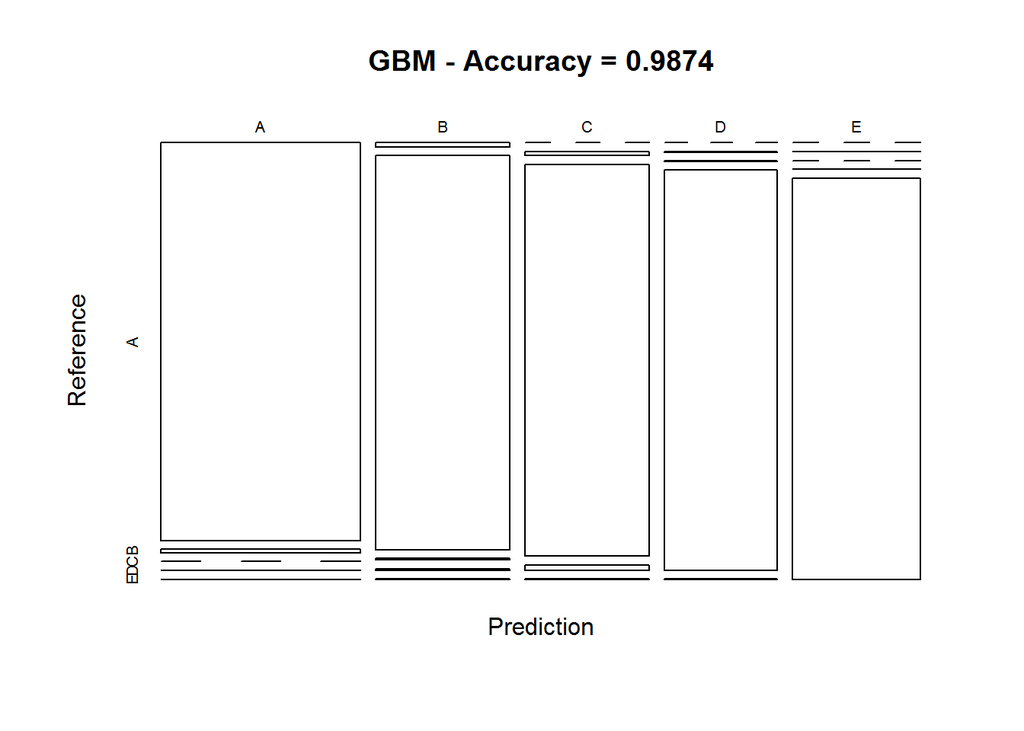

```r
# plot matrix results
plot(confMatGBM$table, col = confMatGBM$byClass,
     main = paste("GBM - Accuracy =",
                  round(confMatGBM$overall['Accuracy'], 4)))
```

## Application to Test Data

The Random Forest model had the highest accuracy at 99.75%, and was applied to predict the 20 test cases. The expected out-of-sample error was 100-99.75=0.25%.

```r
predictTEST <- predict(modRF, newdata=testing)
predictTEST
```

```
##  [1] B A B A A E D B A A B C B A E E A B B B
## Levels: A B C D E
```